# Welcome

## Python Skill Seminar - From absolute 0 to Python hero

*Link to Gitlab repository (this notebook, slides, code and more): https://github.com/perfxweb/python-workshop*

# First of all, thank you!

We've made this skill seminar the most popular one this semester! Again!

## Before we start *(for live class attendees)*

- I need your **full attention**
- Get some coffee ready
- Let me know at ANY time if there are any questions or if we are going too fast
- Turn on your camera (if you're joining online and you want to talk)
- I will have problems to solve for you. Solutions WILL be in the other notebook. Do NOT look at the solutions until we discussed them if you want to learn something.
- close **everything on your computer** except:
  - [this Google Colab notebook (without solutions)](https://colab.research.google.com/github/PerfXWeb/python-workshop/blob/master/Python_CheatSheet_noSolutions.ipynb)
  - (*That Colab notebook has even more notes in it than the presentation itself, so have a look and save it for the future*)

## Your lecturers for today

### [Matthias Hausberger](https://www.linkedin.com/in/matthias-hausberger/)

[figure not shown]

- 23 years old
- Self-taught programmer
- Python, PHP, MySQL, XPath, HTML, CSS, Unix/Linux
- Specialised in web automation (with or without API (Selenium)), and Chat Bots
- Always feel free to contact me: matthias.hausberger@s.wu.ac.at or matthias@perfxweb.com

### [Dario Spoljaric](https://www.linkedin.com/in/dario-spoljaric-436119211/)

[figure not shown]

- 23 years old
- Electrical engineering student at TU (Vienna)
- Experienced in low-level (C, Java) and hardware programming
- Part of the TU Racing team (🏎️ go vroom)
- Always feel free to contact me: e11806417@student.tuwien.ac.at

### PerfXWeb - In case you need professionals

[figure not shown]

perfxweb.com

- We automate EVERYTHING
- Web automation, Mail automation, Data analysis (including Machine Learning)
- Chatbots

We are committed to providing each customer with well-organised, well-documented, secure and reliable solutions.

## Agenda

- *09:00-09:30* - Quick introduction into Python
- *09:30-10:30* - Data Types / Variables (biggest chunk)
- *10:45-11:30* - If sentences
- *11:45-12:45* - Loops
- *12:45-13:00* - Imports (best chunk)
- *13:00-14:00* - **Lunch break**
- *14:00-14:30* - Functions
- *14:30-15:00* - Installing a development environment
- *15:15-16:30* - Live Coding Session
- *16:30-17:00* - Wrap up & next steps

In between:

- Tips and tricks on bug fixing and googling
- exercises
- breaks

## By the end of this class, we should be able to...

- Understand all 5 major concepts of object-oriented programming
- Be able to read and *understand* Python code
- know how to get started with your own code
  - Where to look for code
  - How to avoid common mistakes
  - Intro into working with local computer files, Excel and APIs

Most importantly...

- feel like you learned more in this class than you did in any other class this semester

**This will be a very interactive course**

- Discussions
- Group exercises
- Live coding session
- Feel free to ask questions in between or during breaks
- Using memes (to get you into the programmer memes culture)

*Everything I say, do or think is relevant for the exam at the end (not just the slides!)*

[figure not shown]

## Mindset preparation

- Learning a programming language is like learning any other language
- Vocabulary: not so important (Google is your best friend)
- Grammar (=Syntax): **very important**
- **Watch out on how characters, signs, brackets ()[]{} etc. are all used! Otherwise you will get some errors.**

Today we will learn a lot about the grammar, the baseline of Python programming.

*Side note: At the end of this class, you might feel like you haven't actually learned how to code. But you have. We will get more into that during the live coding session.*

## Google Form Results

### Attendance

[figure not shown]

### Coding Experience

[figure not shown]

### Energy levels

[figure not shown]

"*Quite a stressful week but I will still give a 110%, this is fucking CEMS*"

### Other remarks

- "[...] Invest enough time in basic knowledge [...]"
- "A drink after class together would be highly appreciated!!"

# 0 - Python

## About Python

Python is an interpreted, high-level and general-purpose programming language. Created by Guido van Rossum.

- First release 1991
- Python 3 released in 2008
  - BIG difference to Python 2.7*
- Current version: Python 3.9 *(as of November 2020)*
- Object-oriented programming language *(just like Java, C++, C#, Python, R, PHP, Visual Basic.NET, JavaScript, Ruby, Perl, Object Pascal, Objective-C, Dart, Swift, Scala, Kotlin, Common Lisp, MATLAB, and Smalltalk)*
- very readable code

*(Source: Wikipedia)*

* *Some computers have Python 2.7 pre-installed. Make sure to download and use the current Python 3 version*

> *Advanced: Since many programming languages are object-oriented, you will most probably be able to read code from many many different programming languages to some extent.*

[figure not shown]

## Question!111!!

*Why do we even want to know anything about Python?*

## Why should you even care about Python?

- One of the easiest languages to get into
- Better understanding of software product development
- Salary increases by [up to 25%](https://www.quora.com/What-salary-did-you-manage-to-get-by-learning-Python-by-yourself)
- Absolutely no limits in terms of what is possible to develop

## And why is it so much better than any Excel features?

- No hard limits (Excel is limited to 1 million rows)
- Much faster and lightweight
- Looks much more badass
- Your data validation and calculations are perfectyly **traceable**
- You can combine any Excel sheet analysis with automatically creating PDF reports, sending E-Mails, updating images etc.

## Question!!1!

*What do you think can you develop in Python?*

## What you can do with Python

- Simple algorithms (everything, that excel can do as well)
- Graphs, User Interfaces, Images (diagrams and actual GUI programs)
- Automation in every form you can imagine
- Run code on your computer, phone, server or microwave
- **Data Science and Machine Learning*** *(advanced)*

* *Scikit, Tensorflow, PyTorch and Pandas are known Data Science and Machine Learning tools that all base on Python*

## What you can (or should) NOT do with Python

- GUI games *(possible, but not recommended)*
- Smartphone apps *(possible, but not recommended)*
- low-level programming (possible, usually not recommended)*

* *basically computer language, having access to every detail on how computers use resources*

## What you should know before we start

**Learn the syntax**

Once you understand the syntax, everything else is super easy.

There's always several ways on how to solve a problem.

- Normally, you just need to find **any** way that solves your problem.
- Only if you work for Google etc., you might need to find the "most efficient" code.

Programming mainly consists of:

- 25% **Thinking** about how you can solve a problem
- 5% **Actual coding**
- 70% **Googling**

[figure not shown]

- Most of the time, I also have to google basic commands
- We will learn how to google.
- If you run into any errors during the course - ask me, or...

...google.

## Google Colab - About the environment we are using (to start off)

- An easy way to get started
- Free computing resources
- Easy to share
- Easy to copy to your own Drive
- Nothing needs to be installed on your computer

## If you want to install Python on your own computer (we will have a look at this later)

[Windows tutorial](https://phoenixnap.com/kb/how-to-install-python-3-windows)

[MacOS tutorial](https://docs.python-guide.org/starting/install3/osx/)

**A few tips to bear in mind**:

- Make sure to download Python 3!
- Make sure you also install pip on Python 3 (not on Python 2)
- Maybe have a look at "Python Virtual Environments" for dependency management

# 1 - Data types / Variables

*The beginning of everything*

## Intro

- Variables store values for you **while** you execute your code
  - **Not** for saving those values permanently to then load them another time.
- There are 7 data types, we will go through the most important ones
- You can set and overwrite variables as much as you want.
- You can give your variables *almost* any name you want.
- Special characters: You can *ONLY* use underscores `_`
- Name can not be JUST a number
- Very few names are *reserved names*
  - e.g. `and`, `from`, `if`, `for`, `while`, `try`, `break`,....
- *Do not use CAPITAL LETTERS in your variable names for christ's sake.*

**Unlike other programming languages, Python will automatically use the correct data type once you set up a variable.**

## Strings

Basically any text you want to save

```
# <- anything that you write on the right side of a hashtag
# will serve as a simple comment

# Three ways, all of them are doing the same
cems = "This is some cems variable"
cems="This is some cems variable"
cems = 'This is some cems variable'
# The variable cems now stores some text in it
```

Make sure to watch out for single and double quotes:

```python
# single quotes in a double quote string
cems_single = "Here I've got an abbreviation in my text (I've)."
# double quotes in a single quote string
cems_double = 'Here I can "quote something in double quotes" but not single ones.'
```

```python
# This will not work
cems_single_wrong = 'Here I've got some wrong code'
```

```
  File "<ipython-input-2-686de77f327f>", line 2
    cems_single_wrong = 'Here I've got some wrong code'
                                ^
SyntaxError: invalid syntax
```

*Quick workaround:*

```python
# Backslashes make bad characters harmless
cems_single_double = "Here I've got both single and \"double quotes\" in one variable"

# the print function print() displays whatever you put in between those parantheses
print(cems_single_double)

# Adding up variables also works
cems_single = "Here I've got an abbreviation in my text (I've). "
cems_double = 'Here I can "quote something in double quotes" but not single ones.'
print(cems_single + cems_double)
```

```
Here I've got both single and "double quotes" in one variable
Here I've got an abbreviation in my text (I've). Here I can "quote something in double quotes" but not single ones.
```

### Exercise 1

[figure not shown]

Can you guess what this code does:

```
name = "Matthias"
print("My name is"+name)
```

*Advanced: What might be wrong with the code?*

```python
# Solution
# this defines the variable name to be "Matthias"
name = "Matthias"
# this prints out a string AND then the variable name
print("My name is"+name)

# small bug fix: Add a spacebar in between.
print("My name is "+name)
```

```
My name isMatthias
My name is Matthias
```

## Integers and floats

Numbers you can calculate stuff with.

- Integers are natural numbers without commas
- Floats are numbers with decimals. They always have a comma.

```python
# Define an integer
some_number = 16 # Watch out, there are NO quotation marks!
                 # That way Python knows what is a string and what not
another_number = 4
print(some_number + another_number)

# Define a float
some_float = 16.9
another_float = 3.71
print(some_float + another_float)

# adding another value to an existing variable
another_float = another_float + 2

# add up both
final_result = some_number + another_number + some_float + another_float
print(final_result)
```

```
20
20.61
42.61
```

How to make the result look even cleaner

```python
# we turn that float into an integer
make_an_integer_out_of_this = int(final_result) # int() will always round DOWN
print(make_an_integer_out_of_this)

# round correctly
make_an_integer_out_of_this = round(final_result) # round() does what you expect
print(make_an_integer_out_of_this)

# round to one decimal
make_an_integer_out_of_this = round(final_result, 1)
                          # the round() function can also work with several parameters.
print(make_an_integer_out_of_this)
```

```
42
43
42.6
```

Printing it with text will need some adaptation

```python
# This will NOT work
some_number = 42
print("The number is " + some_number + " and has always been " + some_number + ".")
```

```
---------------------------------------------------------------------------
TypeError                                 Traceback (most recent call last)
<ipython-input-7-8376fb425322> in <module>
      1 # This will NOT work
      2 some_number = 42
----> 3 print("The number is " + some_number + " and has always been " + some_number + ".")

TypeError: can only concatenate str (not "int") to str
```

[figure not shown]

You will have to convert everything to a string before printing it together

```python
# This will work
some_number = 42
print("The number is " + str(some_number) + " and has always been " + str(some_number) + ".")
# str() works in the same way as int()
```

```
The number is 42 and has always been 42.
```

```python
# a much cooler way of printing: use f-strings
# This automatically converts all other data types into a string
# Only works in Python 3
some_number = 42
print(f"The number is {some_number} and has always been {some_number}.")
```

```
The number is 42 and has always been 42.
```

### Exercise 2

[figure not shown]

How can we calculate the average age of Alex and Steve and then tell them "The average age is `XX`."? Round the number to two decimals.

```python
# Your variables
alex = 33.5
steve = 37.75
text = "The average age is "
```

```python
# Solution
average = round((alex + steve) / 2, 2)
```

```python
# Solution
print(text + str(average))
# or
print(f"{text}{average}")
```

```
The average age is 35.62
The average age is 35.62
```

*Nice*

*This is already getting quite sophisticated*

## Booleans

True or False. **Watch out for capitalised letters here!**

```python
is_this_true = True
is_this_false = False

print(is_this_true)
print(f"The other variable says {is_this_false}")
```

```
True
The other variable says False
```

## Lists / Dictionaries / Arrays

One variable that stores a bunch of information.

- Very useful if you have to go through a bunch of information in sequence
- Useful to keep track of all the variables you are using
- One variable can store several data types simultaneously

### Lists

Store several variables in sequence. Use square brackets `[ ]`.

```python
# List example
# each variable gets an index number
# index is:    0        1         2          3
all_names = ["Alex", "Steve", "Patricia", "Karen"] # You MUST use square brackets to define a list

# printing the second list item
print(all_names[1])

# printing the last list item
print(all_names[-1])
```

```
Steve
Karen
```

[figure not shown]

```python
# Advanced:
# printing the first two items (= end at index 1)
print(all_names[:2])

# printing the last two items (= start at -2)
print(all_names[-2:])

# printing every item except the first (= start at index 1)
print(all_names[1:])

# printing the second and third item (= start at index 1, end at index 2)
print(all_names[1:3])
```

```
['Alex', 'Steve']
['Patricia', 'Karen']
['Steve', 'Patricia', 'Karen']
['Steve', 'Patricia']
```

Edit these variables in the same way:

```python
# Editing the item from index 2
all_names = ["Alex", "Steve", "Patricia", "Karen"]
print(all_names)

all_names[2] = "not Patricia anymore"
print(all_names)
```

```
['Alex', 'Steve', 'Patricia', 'Karen']
['Alex', 'Steve', 'not Patricia anymore', 'Karen']
```

You can also define which variable you want to change in another variable

```python
# Editing a variable based on another variable
index_to_change = 3
all_names = ["Alex", "Steve", "Patricia", "Karen"]

all_names[index_to_change] = "I'm changing this"
print(all_names)
```

```
['Alex', 'Steve', 'Patricia', "I'm changing this"]
```

You can also have lists in lists, or dictionaries in dictionaries.

Or if you're feeling really wild: Dictionaries in lists in dictionaries.

```python
# main one, now every name includes an age.
all_names = [["Alex", 25], ["Steve", 28], ["Patricia", 20], ["Karen", 42]]

# we can also append another value
another_woman = ["Olga", 40]
all_names.append(another_woman) # the append() function adds the new item to the END of the list

print(f"The newest member is {all_names[-1][0]} with an age of {all_names[-1][1]}")

# we can also delete a specific value
del(all_names[-2]) # we just deleted Karen out of the equation

print(all_names)
```

```
The newest member is Olga with an age of 40
[['Alex', 25], ['Steve', 28], ['Patricia', 20], ['Olga', 40]]
```

### Dictionaries

Are basically the same as lists, but instead of an integer index, you define the names. Use curly brackets `{ }`.

```python
# dictionaries
hobbies = "Shouting at managers"
user_1 = {'name' : 'Karen', 'age': 42, 'hobbies':hobbies} # MUST use curly brackets.

print(user_1)

# now to print, we STILL use square brackets (don't ask me why)
print(user_1['age'])
```

```
{'name': 'Karen', 'age': 42, 'hobbies': 'Shouting at managers'}
42
```

```python
# changing variables or ADDING new ones is EXACTLY the same as with lists

# changing
user_1['hobbies'] = user_1['hobbies'] + " very loudly" # here I added two more words to the already existing

# adding
user_1['children'] = 0

print(user_1)
```

```
{'name': 'Karen', 'age': 42, 'hobbies': 'Shouting at managers very loudly', 'children': 0}
```

### Exercise 3

[figure not shown]

How can we add another year to Karens age?

```python
# Your variables
users = [
         {'name':'Alex', 'age':25, 'hobbies':'swimming'},
         {'name':'Steve', 'age':28, 'hobbies':'studying'},
         {'name':'Patricia', 'age':20, 'hobbies':'tennis'},
         {'name':'Karen', 'age':42, 'hobbies':'shouting at managers'}
]
```

```python
# Solution
# one line of code
users[3]['age'] = users[3]['age'] + 1
```

## Part 1 - Summary

We learned about

- Strings ( `"hello"` )
- Integers ( `1234` )
- Floats ( `1234.56` )
- Booleans ( `True` )
- Lists ( `[12, 23, "hello"]` )
- Dictionaries ( `{'foo':'bar', 'foo2':'bar2'}` )

*very nice*

*Don't forget: Everything is relevant for the exam at the end of this course.*

[figure not shown]

## Question!!1!

*How do you like the speed of the class so far?*

# 2 - If sentences

*The start of real programming*

## Basics

The two basics of if-sentences are:

- Use `if` to verify whether a condition is met
  - **Indent** all the code that should only be run if that condition is met
- Use `else` after an `if` statement to run code that should be run if a condition is NOT met.
  - **Indent** all the code that should only be run if the `if` condition is not met

*Advanced: Indenation is not common in other programming languages. Most programming languages are using brackets to define what is included for an if-statement.*

Basic example:

```python
# some variables first
my_age = 19

if my_age>=21:
  print("Allowed to drink in the US") # don't forget indentation
else:
  print("Not allowed to drink in the US")
```

```
Not allowed to drink in the US
```

For if-sentences, you can use the following conditions:

- `==`: equal to
- `!=`: not equal to
- `>`: bigger than
- `<`: smaller than
- `>=`: bigger or equal to
- `<=`: smaller or equal to

You can also use any **function** as an if-operator (more on that later). If that function returns `False`, then the condition is not met, otherwise the condition is met.

## `and`, `or` and `in` parameters in if-sentences

If you want to check several conditions at the same time, then you can use the parameters `and` and `or`. If you want to search for a value in a string or list/dictionary/array, you can use `in`.

And they work exactly the way you think they would.

Some examples:

```python
# some variables first
numbers = [19, 23, 39, 30]
string = "This is a string"
person = {'name':'Karen', 'age':23}

if numbers[0]>18:
  print("number is over 18")

if "str" in string:
  print("str is in string")

if "age" in person and "name" in person:
  print("Variable 'person' has a name and an age set!")
```

```
number is over 18
str is in string
Variable 'person' has a name and an age set!
```

Advanced example:

```python
person = {'name':'Karen', 'age':23}

if (person['age']==20 or person['age']==23) and person['name'].lower()=="karen":
  print("Age is 20 or 23 and name is Karen!")

# the variable.lower() function converts all letters into lower-case letters
```

```
Age is 20 or 23 and name is Karen!
```

## Nested if-statements

`if` statements inside `if` statements are called nested if-statements

Example:

Nest 0:

```python
person = {'name':'Karen', 'age':24, 'programming_grade':1}

if person['age']>18:
  print("Person is over 18.")

else:
  print("Person is 18 or under.")
```

```
Person is over 18.
```

Nest 1:

```python
person = {'name':'Karen', 'age':24, 'programming_grade':1}

if person['age']>18:
  print("Person is over 18.")

  if person['programming_grade']<3:
    print("Person's programming grade is lower than 2.")

  else:
    print("Programming grade is higher than 2.")

else:
  print("Person is 18 or under.")
```

```
Person is over 18.
Person's programming grade is lower than 2.
```

Nest 2:

```python
person = {'name':'Karen', 'age':24, 'programming_grade':1}

if person['age']>18:
  print("Person is over 18.")

  if person['programming_grade']<3:
    print("Person programming grade is lower than 2.")

    if person['name']=="Karen":
      print("And the person's name is Karen")
    else:
      print("But the person's name is not Karen")

  else:
    print("Programming grade is higher than 2.")

else:
  print("Person is 18 or under.")
```

```
Person is over 18.
Person programming grade is lower than 2.
And the person's name is Karen
```

...one last thing...

## `elif` statements

*A nice mix of `else` and `if`.*

*If the previous condition is not true, then try this one.*

```python
age = 20

if age>=21:
  print("Allowed to drink everything everywhere.")
elif age>=18:
  print("Not allowed to drink in the US.")
elif age>=16:
  print("Only allowed to drink beer & wine.")
else:
  print("Not allowed to drink at all")
```

```
Not allowed to drink in the US.
```

## Exercise 4 (a big one)

[figure not shown]

Try to program the following:

- We get some random password as an input
- We need to check, whether that password meets the following criteria:
  - The length of the password must be at least 8 characters long *(hint: use `len(variable)` to get the number of characters in a variable)*
  - The password must have at least one uppercase letter in it *(hint: Use `variable.lower()` to convert a variable into lowercase)*
  - The password must have the letter "e" in it
- print an according error message for every condition (using `else` statements
- If all conditions are met, print `"success"`

### Before we start: Excursus to googling Python vocabulary

How to find functions like `len(variable)` or `variable.lower()` if you have no clue about all of this?

[Google: Python variable length (for `len(variable)`)](https://www.google.com/search?q=python+variable+length)

[Google: Python lowercase (for `str.lower()`)](https://www.google.com/search?q=python+lowercase)

### The exercise

```python
# The password variable
password = "Abc25eSdd"
```

```python
# Solution
password = "Abc25eSdd"

if len(password)>7:
  if password.lower()!=password: # this compares the lowercase password with the normal password.
    # If they were equal, it would mean that there is no uppercase letter.
    if "e" in password.lower():
            # I used variable.lower() here again, in case the letter E is capitalised in the password
      print("success")
    else:
      print("The password must include an 'e'")
  else:
    print("The password must include at least one uppercase letter.")
else:
  print("The length of the password must be at least 8 characters long.")
```

```
success
```

[figure not shown]

# 3 - Loops

**Loops**

*Loops*

Loops

...

Loops help you repeat specific code for as long as you need it.

## The difference between `while` and `for` loops

There's two different loop types

- `while` loops - repeat for as long as a condition is True (similar to an if-statement)
- `for` loops - go through each item in a list *(or array, tuple, set, etc.)*

Frankly, both can be used synonymously in a way.

## `while` loops

Basic example: we want to count down until you're allowed to drink in the U.S.

```python
# setting an age
age = 18

while age < 21:
  print(f" Happy birthday! {21-age} more years to go.")
  age = age + 1

print("Happy birthday! You're allowed to drink now!")
```

```
 Happy birthday! 3 more years to go.
 Happy birthday! 2 more years to go.
 Happy birthday! 1 more years to go.
Happy birthday! You're allowed to drink now!
```

## `for` loops

Basic example: We want to greet everyone in a list

```python
# setting a few names in a list
names = ['Mark', 'Steve', 'Elon', 'Melinda', 'Bill', 'Angela', 'Melania']

for i in names:
  # In this for loop, 'i' is a temporary variable that will be
  # set as the current item of the list for the current loop.
  # We can name this temporary variable any way we want.
  print(f"Hello {i}")
```

```
Hello Mark
Hello Steve
Hello Elon
Hello Melinda
Hello Bill
Hello Angela
Hello Melania
```

[figure not shown]

Loops are often used to go through a dataset perform an action on each entry:

```python
names = [['Mark', 22], ['Steve', 45], ['Elon', 55], ['Melinda', 18],
         ['Bill', 24], ['Angela', 20], ['Melania', 70]]

for i in names:
    # checks if person is at least 21 years old
    if i[1]>=21:
        print(f"{i[0]} has reached the legal drinking age")
    else:
        print(f"{i[0]} is too young!")
        # maybe do some database updating here or something
```

```
Mark has reached the legal drinking age
Steve has reached the legal drinking age
Elon has reached the legal drinking age
Melinda is too young!
Bill has reached the legal drinking age
Angela is too young!
Melania has reached the legal drinking age
```

As always, we can also combine several if-statements and for-loops *(advanced)*:

```python
# setting up names with bank balances (assuming people have several banks)
names = [
         {'name':'Mark', 'bank_balances':[45,234,964,233,112]},
         {'name':'Steve', 'bank_balances':[1234,23,22]},
         {'name':'Elon', 'bank_balances':[420,69,365,1010]},
         {'name':'Melinda', 'bank_balances':[831,44,244,223]},
         {'name':'Bill', 'bank_balances':[34,353,3555,7742,3]},
         {'name':'Angela', 'bank_balances':[39,22,2]},
         {'name':'Melania', 'bank_balances':[383,335,2,66,24]}
        ]

for name in names:
  if 'name' in name and 'bank_balances' in name: # just checks if the variables we need are set

    curr_balance = 0 # we use this variable to add up the balances every time
    for value in name['bank_balances']:
      curr_balance = curr_balance + value

    print(f"{name['name']} has a total balance of: {curr_balance}")
```

```
Mark has a total balance of: 1588
Steve has a total balance of: 1279
Elon has a total balance of: 1864
Melinda has a total balance of: 1342
Bill has a total balance of: 11687
Angela has a total balance of: 63
Melania has a total balance of: 810
```

### `range()` function

`range()` creates somewhat of a list of numbers with the range you specify. The `for` loop will loop through those numbers.

```python
for i in range(10):
  print(f"printing number {i} out of 10")
  # remember, lists start at value 0. This will only count up to number 9
```

```
printing number 0 out of 10
printing number 1 out of 10
printing number 2 out of 10
printing number 3 out of 10
printing number 4 out of 10
printing number 5 out of 10
printing number 6 out of 10
printing number 7 out of 10
printing number 8 out of 10
printing number 9 out of 10
```

```python
# if you want to count from 1 to 10, you have to set a starting number and an end number
for i in range(1,11):
  print(f"printing number {i} out of 10")
```

```
printing number 1 out of 10
printing number 2 out of 10
printing number 3 out of 10
printing number 4 out of 10
printing number 5 out of 10
printing number 6 out of 10
printing number 7 out of 10
printing number 8 out of 10
printing number 9 out of 10
printing number 10 out of 10
```

## Exercise 5 (another big one)

[figure not shown]

- We are given a dataset with some emission values
- We need to calculate the average of all emission values BUT we want to exclude values that are too large from our average (i.e. basically forging data aka. "ignoring false measurements")
- Calculate the average of all values where the emission value is LOWER than 10

*Hints:*

- *There's MANY ways on how you could solve this issue*
- *use a `for` loop. (simplest way)*
- *Depending on how you solve it, you might need your own `count` variable (or similar) to count the number of values that you are averaging (so you know what number to divide your sum with).

```python
# your variables
people = [11.3, 7.5, 3.6, 7.7, 3.5, 9.9, 10.0, 8.4, 4.4, 7.6, 2.5, 14.5, 6.9, 9.6]
```

## Question!!1!!11

*How of you is still somewhat keeping up? Anyone who's lost completely?*

```python
# Solution (1) - the not so elegant way
divide = 0 # counting the number of valid entries
total = 0 # summing up all valid entries
for i in people:
    if i<10: # if entry is valid, update our variables
        total = total + i
        divide = divide + 1

average = total / divide # calculate average
print(average)
```

```
6.509090909090909
```

```python
# Solution (2) - much more elegant (using remove(), sum() and len())
for i in people:
    if i>=10: # if entry is valid, remove from that list
        people.remove(i)

average = sum(people) / len(people) # calculate average

print(average)
```

```
6.509090909090909
```

```python
# Solution (3) - fancy way using numpy (a very popular Python package for data analysis)
import numpy as np

people_array = np.array(people) # turn list into a Numpy array
people_array_filtered = people_array[i < 10] # filter out all invalid entries
average = np.average(people_array_filtered) # calculate average

print(average)
```

```
6.509090909090909
```

```python
# Solution (4) - Basically Solutoin 3 but much slicker
import numpy as np
average = np.average(np.array(people)[i < 10])
print(average)
```

```
6.509090909090909
```

# 4 - Imports

*You can now do more with Python than you think*

So far, we have learnt a lot about the Python syntax... but some of you might think they still can't really program anything useful.

[figure not shown]

YOU can actually now achieve ANYTHING with imports!

**GOOGLE is your best friend**

Some examples of useful modules:

```python
import time # we have already used the time module before

print(time.time()) # prints out UNIX timestamp (number of seconds since Jan 1 1970)
time.sleep(5) # waits for 5 seconds
print(time.time())
```

[output not shown]

```
1634230803.7939122
1634230808.8010051
```

A good example of how I failed to use this API (Application Programming Interface):

```python
import requests

# Chuck Norris API: https://api.chucknorris.io

joke = requests.get("https://api.chucknorris.io/jokes/random")
#print(joke) # this usually prints out everything.
            # Unfortunately, "joke" is now an object, so we don't see anything
#print(joke.__dict__) # __dict__ shows you every attribute of an object. That way we can find out more.
print(joke.content['value']) # I wanted to print out the value, but it didn't work

# Looked it up on Google...
```

```
---------------------------------------------------------------------------
TypeError                                 Traceback (most recent call last)
<ipython-input-45-b3d493cccb38> in <module>
      7             # Unfortunately, "joke" is now an object, so we don't see anything
      8 #print(joke.__dict__) # __dict__ shows you every attribute of an object. That way we can find out more.
----> 9 print(joke.content['value']) # I wanted to print out the value, but it didn't work
     10
     11 # Looked it up on Google...

TypeError: byte indices must be integers or slices, not str
```

Solved it using [this Stackoverflow post](https://stackoverflow.com/questions/52102398/typeerror-byte-indices-must-be-integers-or-slices-not-str/52102506).

[figure not shown]

```python
# turns out I need to convert from a JSON format into a normal Python dictionary format
import requests
import json

joke = requests.get("https://api.chucknorris.io/jokes/random")
result = json.loads(joke.content)
print(result['value'])
```

```
Chuck Norris can tell the time at night with the use of a flashlight alone.
```

Another useful example:

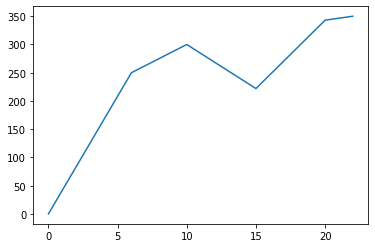

```python
# this uses a module within a module (matplotlib.pyplot) and renames it to plt
import matplotlib.pyplot as plt
# we can always rename modules to write less code
import numpy as np

xpoints = np.array([0, 6, 10, 15, 20, 22]) # creates an array (a REAL array) with all x-values
ypoints = np.array([0, 250, 300, 222, 343, 350]) # same for y-values.
# Both arrays need to have the same amount of values!

plt.plot(xpoints, ypoints) # this plots all values into a graph
plt.show() # this shows it on the display (similar to print)
```

We can already guess what this code does by looking at the names of the objects and methods. If we are still unsure, we can just [google it](https://www.google.com/search?q=python+plt.plot&ie=UTF-8&oe=UTF-8).

Now guess what this code does:

```python
import selenium_framework
# selenium_framework is a module I built myself. The usual approach would be "import selenium"
# Selenium itself does exactly the same as I do here, yet it requires a bit more code.
# If you are able to install Python, pip and selenium on your computer successfully, message me....
# .... I will send you the selenium_framework module via Gitlab.
import time

username = "h11706787"
password = "XXXXXXXXXXXX"
course = "International Diversity Management"
lv_number = "1052"

sf = selenium_framework.SeleniumBrowser("macos")

sf.start_driver()
driver = sf.driver

driver.get("https://lpis.wu.ac.at/lpis")
time.sleep(3)
sf.find_xpath('//input[@type="text"]').send_keys(username)
time.sleep(1)
sf.find_xpath('//input[@type="password"]').send_keys(password)
time.sleep(1)
sf.find_xpath('//input[@type="submit"]').click()
time.sleep(5)
sf.find_xpath(f"//span[text()='{course}']/ancestor::td//a[contains(text(),'anmelden')]").click()
time.sleep(5)
sf.find_xpath(f"//a[text()='{1052}']/ancestor::tr//input[@type='submit']").click()
```

Yes. This automatically signs you up to a course in LPIS.

One last one. What does this one do:

```python
import pandas as pd
import numpy as np
from sklearn.model_selection import train_test_split
import tensorflow as tf

trial = pd.read_csv('https://raw.githubusercontent.com/Elmira-Rakhmetova/ML-Audit-project/main/trial.csv')
trial = trial[(trial.LOCATION_ID != 'LOHARU') & (trial.LOCATION_ID != 'NUH') & (trial.LOCATION_ID != 'SAFIDON')].astype(float)
trial[np.isnan(trial)] = 0
x = trial[['PARA_A','PARA_B', 'TOTAL', 'numbers', 'Money_Value', 'District', 'Loss', 'History']]
y = trial['Risk'].astype(int)
x = tf.keras.utils.normalize(x)
x_train, x_test, y_train, y_test = train_test_split(x, y, test_size=0.3, random_state=42)

dnn_model = tf.keras.models.Sequential([
tf.keras.layers.InputLayer(input_shape=(8)),
tf.keras.layers.Dense(50, activation='relu'),
tf.keras.layers.Dropout(0.2),
tf.keras.layers.Dense(20, activation='relu'),
tf.keras.layers.Dense(2)
])

dnn_model.compile(optimizer='adam',
              loss=tf.keras.losses.SparseCategoricalCrossentropy(from_logits=True),
              metrics=['accuracy'])

result = dnn_model.fit(x_train, y_train, epochs=1000)
```

Yes. That is a deep neural network (machine learning stuff) that predicts some data. Machine Learning. Not as magical as it seems.

# Quick recap before lunch

## What we learnt so far

- Data types (strings, integers, floats, booleans, lists, dictionaries)
- If-sentences (nested ifs, elif,...)
- Loops (while, for, range() function)
- Imports (plus examples)

## Any questions?

[figure not shown]

# 5 - Functions

*write code once, use it several times*

We have already used functions before in our code:

```
print("hello world") # prints something onto the display
len(variable) # returns the length of a string or array
del(variable[2]) # deletes an item out of a list
```

Now we are going to learn how to create our own functions

## Defining a function

Works like this:

```python
def myfunction():
  print("Every time I call this function, this is printed")
```

now we can call this function

```python
myfunction()
```

```
Every time I call this function, this is printed
```

## Adding arguments

Works like this:

```python
def greeting(name):
  print(f"This is a message for {name}")
```

now we can call this function using a parameter

```python
greeting("Elena")
greeting("John")
```

```
This is a message for Elena
This is a message for John
```

Now, if we don't define this argument, the function will fail:

```python
# this will NOT work
greeting()
```

```
---------------------------------------------------------------------------
TypeError                                 Traceback (most recent call last)
<ipython-input-52-b450c4c5145c> in <module>
      1 # this will NOT work
----> 2 greeting()

TypeError: greeting() missing 1 required positional argument: 'name'
```

What we can do so this doesn't happen: Pre-define arguments

```python
def greeting2(name="Elton"):
  print(f"This is a message for {name}")
```

Now, we can call this variable *with* or *without* setting the parameter:

```python
greeting2()
greeting2("Jessica")
```

```
This is a message for Elton
This is a message for Jessica
```

## Returning a result from a function

Let's create a function that calculates interest:

```python
def calculate_interest(capital, interest, years):
  capital = round(capital*interest**years)

  # now return the result (without printing)
  return capital
```

Now, using that function, we can calculate interest really quickly:

```python
my_interest = calculate_interest(1000, 1.05, 15)
print(f"We calculated a future capital of {my_interest}")

# or we could also just use:
print(f"We calculated a future capital of {calculate_interest(1000, 1.05, 15)}")
```

```
We calculated a future capital of 2079
We calculated a future capital of 2079
```

## Exercise 6

[figure not shown]

Create a function that returns the average of three given numbers. The result should look like this:

```
result = average_calc(11, 13, 25)
print(result)
```

*Bonus: Functions support lists (`[11, 13, 25]`) as a parameter. If possible, create a function that returns the average of any amount of numbers.*

```python
# Solution
def average_calc(no1, no2, no3):
  return (no1+no2+no3)/3


result = average_calc(11, 13, 25)
print(result)
```

```
16.333333333333332
```

```python
# Solution (Bonus)
def average_calc(numbers):
  return sum(numbers)/len(numbers)


result = average_calc([11, 13, 25])
print(result)
result = average_calc([11, 13, 25, 22, 2, 99])
print(result)
```

```
16.333333333333332
28.666666666666668
```

# Installing a real development environment on our computers

- The first steps towards becoming a pro developer

## There's two options for you guys now

### Option 1: Being a lazy ass

- Pro: Lean back, watch us code live and see other people struggle.
- Con: You will forever be a noob in programming.

### Option 2: Go all in

- Pro: You're a HUGE step closer to actually using Python in the future.
- Con: Your head might start smoking

## We will be installing:

- Python3 and a package manager that comes with it
- An IDE
  - "Integrated Development Environments" help us to code much faster and more efficiently
  - In theory, you can use any text editor, but programming makes more fun with an IDE!
  - Personally, we're using [Visual Studio Code](https://code.visualstudio.com)
  - If you don't have an IDE already, just download this one.

[figure not shown]

## Installation guide

1. Install an IDE of choice (we recommend and support you installing [Visual Studio Code](https://code.visualstudio.com)
2. Follow all the prompts
3. Install [Python 3 (the latest)](https://www.python.org)
4. Open a terminal in your IDE:
5. Enter the following into your terminal window and press enter: `python --version` OR `python3 --version` OR `py --version`
6. Make sure you have a Python 3 version
7. Then, use your python command to also check if pip is working: `python3 -m pip --version`

Should look like this:

[figure not shown]

*Quick troubleshooting*

- *If pip is not installed, google on how to install pip.*
- *If you cannot open Python via your terminal (some kind of "not found" error) then google on how to set PATH variables for Python on your operating system.*

## Let's get to it!

[figure not shown]

# LIVE CODING SESSION

*Let's get this started*

## Checking out our environment

1. Is our IDE ready and a project folder is set up?
2. Is Python installed correctly?
3. Is our Terminal/Debugging tool ready?

## Project 1 - Validating and correlating stock market data

*(Source Code in sample_code/project_stock_correlation)*

### The issue

- We have raw data about two stocks
- Some dates and values are missing
- We want to clean the data and do some visualisation and maybe some correlation

### The solution

- Open the file in Python
- Use loops to go through all entries and validate them
- Write the cleaned dataset into another Excel sheet
- Create some visualizations and a correlation using matplotlib and sklearn

## Project 2 - Automatically keeping your Downloads-folder clean

*(Source Code in sample_code/project_download_folder)*

### The issue

- I keep downloading stuff from the internet and my downloads folder gets cluttered
- I don't want any files to be deleted but rather to be restructured
- My downloads folder should look clean and accessible after running the program
- There should be an option to keep specific files in the downloads folder if I want to

### The solution

1. All files should be restructured based on their type:
   - Image files (.png, .jpg, .jpeg, .gif, ) should be moved to an "images" folder
   - Video files (.mov, .mp4) should be moved to a "videos" folder
   - Music files (.mp3, .wav, , .aac) should be moved to a "music" folder
   - Documents (.doc, .docx, .pdf, .ppt, .pptc, .xls, .xlsx) should be moved to a "documents" folder
   - Zip files (.zip, .tar, .tar.gz) should be moved to a "zips" folder
   - Any folders that are NOT the ones above should also be moved to the "zips" folder
2. Files that start with "x " should always be kept in the main downloads folder
3. If any of the folders above does not exist within the Downloads folder, then we need to create it

## Project 3 - Correlating COVID-19 data with a company Excel sheet

*A fictional case on how to use Python at your workplace*

*(Source Code in sample_code/project_covid_happiness)*

### The issue

- We work in an Austrian company and are responsible for some organisational kinda stuff
- We were given a bunch of Excel sheets, one for EACH employee of our company
  - Each Excel sheet contains the individual employee's happiness level for each week of the year
- We want to know if there are general happiness trends throughout the year within the company
- We also feel like the whole thing has something to do with COVID...
- Naturally, we want to see if we can correlate the average happiness with some COVID data.

### The solution

This is quite a sophisticated task already. But We CAN DO IT!!11!1!!

Our program shall do the following:

1. Go through all Excel sheets in a specific folder using a for loop
   - Read out the happiness levels of each employee-sheet and temporarily save them
2. Open another Excel sheet and enter the AVERAGE of the happiness of all employees in that sheet
3. Get "total confirmed cases of COVID-19" of AUSTRIA of the past months and add that data next to our employee-happiness-average

*(We could then do some crazy correlation stuff using Python as well but.... this is no Data Science class, sorry)*

Beaautttiiifffuuuullll

All of the code for these projects can be found on the [Github repository](https://github.com/PerfXWeb/python-workshop).

# Exam

*Wohoo, well done! You all passed!*

```python
def making_everyone_pass(students):
    for i in students:
        print(f"{i} passed!")

students = ["Iaroslav", "Syed", "Ilya", "Blanka", "Aleksandra", "Alexander", "Matteo", "Mario", "Artemii", "Adam", "Piotr", "Jakub", "Peishan", "DANIEL", "Nadia", "Moritz", "Marcin", "Sándor", "Etienne", "Fanni", "Alberto", "Matthias", "Christine ", "Filip", "Sebastian", "Elmira", "Franziska", "Anika", "Jakob", "Jonathan", "Maura", "Elisabeth"]
making_everyone_pass(students)
```

```
Iaroslav passed!
Syed passed!
Ilya passed!
Blanka passed!
Aleksandra passed!
Alexander passed!
Matteo passed!
Mario passed!
Artemii passed!
Adam passed!
Piotr passed!
Jakub passed!
Peishan passed!
DANIEL passed!
Nadia passed!
Moritz passed!
Marcin passed!
Sándor passed!
Etienne passed!
Fanni passed!
Alberto passed!
Matthias passed!
Christine  passed!
Filip passed!
Sebastian passed!
Elmira passed!
Franziska passed!
Anika passed!
Jakob passed!
Jonathan passed!
Maura passed!
Elisabeth passed!
```

# That's it!

*What a journey this has been!*

**Before we wrap this up:**

Please fill out my [feedback form](https://forms.gle/x5r6jn5ekGcx2pD98)

[figure not shown]

## Some final tips from the pro programmers

- **COMMENT your code** or else it will get real messy real fast

[figure not shown]

- Most of the projects have already been done. Copy code from Github or other sources and adapt them to your desire. Just GOOGLE IT!
- Most of the work while programming is finding out how stuff works and bug fixing. Don't get frustrated too quickly

## What we learnt

- A LOT about the syntax of Python
  - Data types (strings, integers, floats, booleans, lists, dictionaries)
  - If-sentences (nested ifs, elif,...)
  - Loops (while, for, range() function)
  - Functions (arguments in functions, return,...)
  - Imports (plus examples)
  - (didn't learn about classes and objects but you can go through the slides on your own)
- How to use Python on your own computer
- How to use Python with Excel
- How to connect to an API and parse data
- How to read error messages
- Where and how to look for solutions (Google, Stackoverflow)

# Where to go from here?

## What you might wanna do now

- Go find something you want to program yourself
- Have a look at some APIs out there (social medai APIs, stock market APIs, Google Docs APIs,...)
- Use Python to calculate or automate stuff.
- Have a look at common Python packages (Numpy, SciKit, requests, ....)

Some examples *(you will have to install Python on your computer)*:

- Automatically back up specific data on your computer to a usb.
- Automatically calculate your current stock values with a stocks API
- Keep track of prices of certain Amazon products and get notified when the price drops
- Use Python for Data Science or Machine Learning projects

Find more cool ideas for Python projects in [this video](https://www.youtube.com/watch?v=o5sb8ehRSYA) (general ideas), [this video](https://www.youtube.com/watch?v=qbW6FRbaSl0&t=57s) (automation stuff) or [that video](https://www.youtube.com/watch?v=OXi4T58PwdM) (GUI stuff)

## Further useful resources

- Learn more Python syntax: [w3schools (very similar to this)](https://www.w3schools.com/python/)
- Have a look at [databases to store data](https://www.w3schools.com/python/python_mysql_create_db.asp)
- Go all in with [machine learning and Tensorflow (advanced)](https://www.udacity.com/course/intro-to-tensorflow-for-deep-learning--ud187)

## If you have any questions, feedback or want to share what you where able to do with the help of this Python Workshop

**Contact me** at matthias.hausberger@s.wu.ac.at

**If you, your company, your project, your family or anyone you know needs absolute professionals in automating ANYTHING:**

[figure not shown]

perfxweb.com

Or contact me: matthias@perfxweb.com

Thank you!

# 6 - Classes and object (for you to do at home if you're feeling adventurous)

*Something really advanced .... But it's good to know the basics of object-orientation*

The main reason why we learn what classes are:

- Basically everything in Python is based on it.

## The Big Picture

classes, objects, methods (basically functions), attributes

[figure not shown]

- A **class** is the blueprint to create objects
  - You can create as many objects from one class as you like
  - You can also pass arguments while creating an object
- An **object** preserves both attributes (data) and methods (functions)
  - It's basically a mix between an array and a bunch of functions.
- **Methods** are functions that can be executed within an object.
- **Attributes** save values of an object

## And it looks like this

```python
# creating a class
class Tree():
  # the __init__ function (two underscores left and right) is only being executed ONCE
  # when you create a new object.
  def __init__(self, branches, apples):
    # every object automatically passes ITSELF to every function. It is commonly defined as "self"
    # We ALWAYS need to define this "self" argument at the beginning of each object function
    self.branches = branches
    self.apples = apples
    self.carved_in_names = []

  def carve(self, name):
    self.carved_in_names.append(name)
    print(f"Successfully carved in {name}")
    # if we want, we can return something, but we don't really have to
    return self.carved_in_names

  def look_at_carved_names(self):
    print(f"Look at all these carved in names: {self.carved_in_names}")
```

```python
# now, we'll create two different trees
tree1 = Tree(8, 15)
tree2 = Tree(3, 0)
```

```python
# we can check for the number of branches and apples (=attributes) in each tree like this:
print(tree1.branches)
print(tree2.apples)

# we can also change it:
tree1.branches = 10
print(tree1.branches)
```

```
8
0
10
```

```python
# now let's carve in some names into our trees using methods:
tree1.carve("Matthias")
tree2.carve("Brad")
tree2.carve("Sophie")

# and we can check out the number of carved-in names by performing our other method:
tree2.look_at_carved_names()
```

```
Successfully carved in Matthias
Successfully carved in Brad
Successfully carved in Sophie
Look at all these carved in names: ['Brad', 'Sophie']
```

## Exercise 7 (the last one)

[figure not shown]

- create a class called `Flipflop` with an integer `div` (a number) as an argument
  - `check1 = FlipFlop(3)`
- create a method `divisible` (=function) in that class with another integer `maxint` as an argument. The function shall loop x times and print out "flip", whenever the current number is not divisible by `div`, or print out "flop", whenever the current number *is* divisible by `div`.
  - `check1.divisible(100)`

This shall print out:

```
0: flop    # flop first, because we always start at 0
1: flip
2: flip
3: flop
4: flip
5: flip
6: flop
...
```

*Bonus exercise:*

- *Create another method `divisible_or_self` that not only prints "flop" when the number is divisible by `div` but also if one of the digits of the current number is equal to `div`*
  - *e.g. if `div` is 3, then the number 13, 133 or 35 should "flop" as well</i>*

**Important:** Google it, if you don't know how to do it.

E.g. "Python check if divisible"

```python
# Solution

class FlipFlop():
  def __init__(self, div):
    self.div = div

  def divisible(self, maxint):
    for x in range(maxint):
      if x % self.div == 0:
        print(f"{x}: Flop")
      else:
        print(f"{x}: Flip")


check1 = FlipFlop(3)
check1.divisible(100)
```

```
0: Flop
1: Flip
2: Flip
3: Flop
4: Flip
5: Flip
6: Flop
7: Flip
8: Flip
9: Flop
10: Flip
11: Flip
12: Flop
13: Flip
14: Flip
```

[output cut: 85 more lines]

```python
# Solution (incl. bonus)

class FlipFlop():
  def __init__(self, div):
    self.div = div

  def divisible(self, maxint):
    for x in range(maxint):
      if x % self.div == 0:
        print(f"{x}: Flop")
      else:
        print(f"{x}: Flip")

  def divisible_or_self(self, maxint):
    for x in range(maxint):
      if x % self.div == 0 or str(self.div) in str(x):
                              # to check every digit, we have to use str() to convert it.
                              # otherwise we get an "argument of type 'int' is not iterable" error.
        print(f"{x}: Flop")
      else:
        print(f"{x}: Flip")


check1 = FlipFlop(3)
check1.divisible_or_self(100)
```

```
0: Flop
1: Flip
2: Flip
3: Flop
4: Flip
5: Flip
6: Flop
7: Flip
8: Flip
9: Flop
10: Flip
11: Flip
12: Flop
13: Flop
14: Flip
```

[output cut: 85 more lines]